# Trabajo Fundamentos Matemáticos

## Estudio en base a la primera campaña aceptada

En el apartado anterior se han analizado las relaciones y las diferencias existentes entre aquellos clientes que aceptan alguna de las campañas y aquellos que no lo hacen en ninguna ocasión. Asimismo, en este apartado se quieren estudiar las características de aquellos clientes que aceptan por primera vez las promociones ofrecidas en la misma campaña.

Se crea una columna, llamada “AcceptCmp” que almacena el dato del número de campaña en el que ha aceptado cada cosnumidor por primera vez, 0 en caso de no haberla aceptado en ninguna ocasión.

```r
datos_acceptcmp = datos[,-1]

AcceptCmp = c(0)
datos_acceptcmp = cbind(datos_acceptcmp, AcceptCmp)


for (i in 1:nrow(datos_acceptcmp)){
  for (j in 1:6){
    if (datos_acceptcmp[i,j]==1 & datos_acceptcmp[i,30]==0){
      datos_acceptcmp$AcceptCmp[i]=j
    }
  }
}

datos_acceptcmp = datos_acceptcmp %>%
  filter(Year_Birth>1920) %>%
  filter(Income<6e+5)

datos_acceptcmp %>%
  select(AcceptCmp) %>%
  head()
```

```
##   AcceptCmp
## 1         6
## 2         0
## 3         0
## 4         0
## 5         0
## 6         0
```

A continuación se seleccionan únicamente las observaciones de aquellos clientes que han aceptado alguna de las campañas y se muestra cuantas personas lo hacen en cada una de las ocasiones.

```r
datos_acceptcmp = datos_acceptcmp %>%
  select(,c(1:30)) %>%
  filter(AcceptCmp>0)
```

```r
datos_acceptcmp = datos_acceptcmp %>%
  mutate(AcceptCmp=factor(AcceptCmp))
datos_acceptcmp %>%
  count(AcceptCmp)
```

```
##   AcceptCmp   n
## 1         1 142
## 2         2  17
## 3         3 135
## 4         4 107
## 5         5  57
## 6         6 146
```

Como se puede observar en esta tabla, la mayoría de clientes han aceptado por primera vez en las campañas 1, 3 y 6, siendo esta última la mayoritaria de las estudiadas.

A continuación se van a estudiar diferentes características de los clientes para ver si estas tienen relación con la primera campaña que aceptan.

#### MEDIA DE EDAD

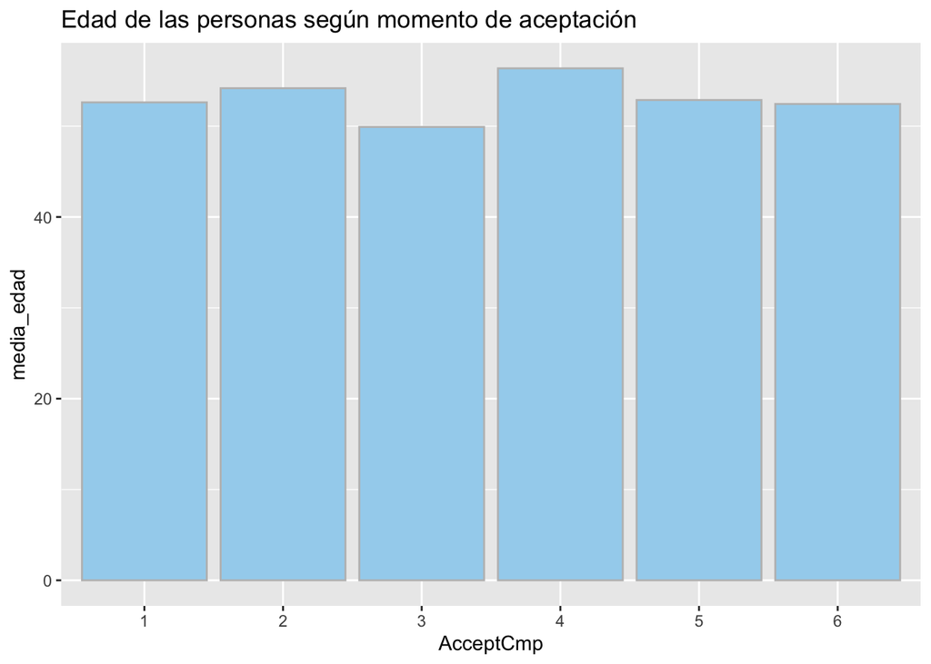

```r
datos_acceptcmp %>%
  group_by(AcceptCmp) %>%
  summarise(media_edad = mean((2021-Year_Birth))) %>%
  ggplot(aes(x=AcceptCmp, y=media_edad)) +
  geom_col(color="grey", fill="lightskyblue2") +
  ggtitle("Edad de las personas según momento de aceptación")
```

En este gráfico se puede apreciar que no hay mucha diferencia entre la edad de las personas que aceptan en las diferentes campañas. No parece ser significativa la edad para estudiar en qué momento se acepta la campaña.

#### EDUCACIÓN

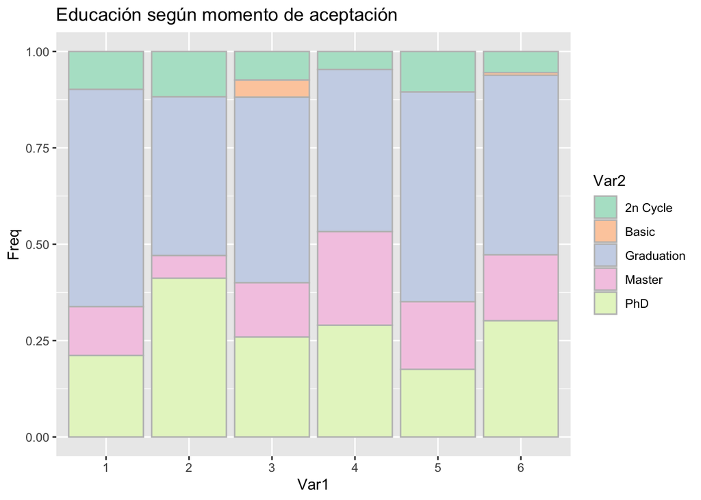

```r
table_educ = table(datos_acceptcmp$AcceptCmp, datos_acceptcmp$Education)
propt_educ = as.data.frame(prop.table(table_educ, margin=1))

ggplot(propt_educ,aes(x=Var1,y=Freq,fill=Var2)) + geom_col(color="grey") +
  scale_fill_brewer(palette="Pastel2") +
  ggtitle("Educación según momento de aceptación")
```

De este gráfico se puede concluir que la educación no es una variable que afecte mucho a la hora de decidir por primera vez aceptar una campaña, aunque sí que hay que mencionar la cantidad de clientes de PhD que aceptan por primera vez en la segunda campaña, que además es la campaña en la que menos clientes han aceptado las promociones ofrecidas, como se ha visto antes.

#### ESTADO CIVIL

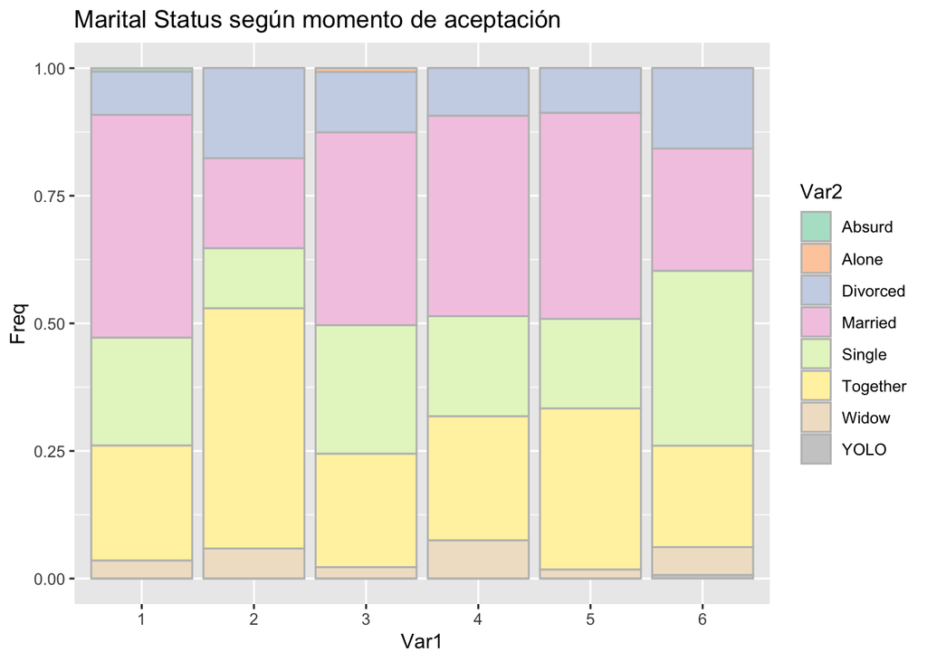

```r
table_marit = table(datos_acceptcmp$AcceptCmp, datos_acceptcmp$Marital_Status)
propt_marit = as.data.frame(prop.table(table_marit, margin=1))

ggplot(propt_marit,aes(x=Var1,y=Freq,fill=Var2)) + geom_col(color="grey") +
  scale_fill_brewer(palette="Pastel2") +
  ggtitle("Marital Status según momento de aceptación")
```

Como muestra el gráfico, los clientes que tienen pareja representan más de la mitad de los clientes que aceptan por primera vez en la segunda campaña. Además, los divorciados, aceptan más las promociones en la segunda y en la sexta campaña, y por otro lado los solteros lo hacen más en la última ocasión.